[figure not shown]

WI-436

Bulkhead Wiring Harness (In Compartment) LH

WIRING SYSTEM

65.Bulkhead Wiring Harness (In Compartment) LH

A: LOCATION

1. ENGINE TYPE FA

Connector Connecting to

No. Pole Color Area No. Description

AB1 10 GR D-1 B31 Bulkhead wiring harness

AB2 4 Y C-5 AB7 Driver’s airbag module

AB66 2 B C-3 Driver’s knee airbag module

B23 10 B-2 B28

Bulkhead wiring harness (with push button start)

B28 10 B-2 B23

B31 10 GR D-1 AB1 Airbag wiring harness

B32 8 B-3 Turn signal and hazard unit

B40 16 B C-2 Data link connector

B41 2 C-2 Power window circuit breaker

B52 24 C-2 F/B

B54 48 B C-2 TCM

B65 4 B B-3 Stop light and brake switch

B68 14 C-5 ST1 Roll connector

B70 10 C-5

Combination switch

B71 20 C-4

B72 8 C-4 Ignition switch (without push button start)

B77 6 C-3 Mode door actuator

B92 10 D-2 R5

Rear wiring harness LH

B99 24 D-1 R3

B101 8 B D-2 D11 Front door cord LH

B106 2 B-2 Clutch start switch

B107 2 L C-2 Clutch switch

B123 2 D-2

Key lock (without push button start)

B124 2 D-2

B150 24 B-2 Auto headlight beam leveler CM

B152 10 GR C-2

F/B

B158 8 C-2

B159 9 C-2

B162 2 C-2

B180

4 B-2 Remote engine start CM (without push button start)

8 B-2 Remote engine start CM (with push button start)

B181 2 C-2 B182

Bulkhead wiring harness

B182 2 C-2 B181

B225 44 C-2 Relay holder

B231 5 C-5 Steering angle sensor

B235 6 B-4 Air mix door actuator LH

B280 34 B-2

Body integrated unit

B281 35 B-2

B315 6 B B-4 Accelerator pedal position sensor

B367 8 B-3 Impact sensor

B415 7 B C-5 Immobilizer antenna (without push button start)

B422 5 A-4 ID code box

B424 7 B C-4 Steering lock CM (with push button start)

B426 4 B C-3 Accessory relay (with push button start)

[figure not shown]

WI-437

Bulkhead Wiring Harness (In Compartment) LH

WIRING SYSTEM

B475 4 C-3 Wiper relay unit

B550 26 B C-3 Fuse holder

B551 12 C-3 i229

Instrument panel wiring harnessB552 17 GR C-3 i230

B553 20 C-3 i231

B555 2 C-5 Key warning switch (without push button start)

B557 2 C-4 Key lock solenoid (without push button start)

B558 7 C-5 Combination switch

B559 5 A-4 Security CM

B572 18 C-2

Keyless access CMB573 28 B-2

B574 30 B-2

B575 22 B-1 B576

Bulkhead wiring harness (with push button start)

B576 22 B-1 B575

: White or natural color

Connector Connecting to

No. Pole Color Area No. Description

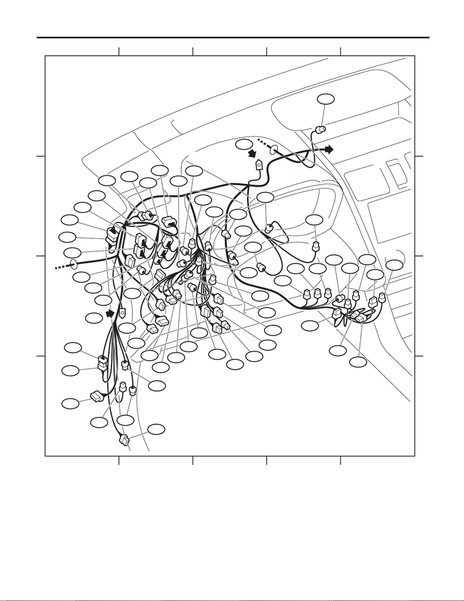

WI-438

Bulkhead Wiring Harness (In Compartment) LH

WIRING SYSTEM

WI-44617

12345

12345

A

B

C

D

A

B

C

D

RH

GB-3

B281

B225

B41

B54

B107

B159

B52

B40

AB1

B31

B99

B101

B92

B123

B124

B152

B158

B550

B182

B553

AB66

B551

B162

B475

B181

B552

B572

B576

B573

B280

B23

B574

B150

B106

B180

B426

B367

B32

B65

B77

B315

B235

B424

B72 B557

B415

B231

B555

B71

AB2

B68

B70

B558

B28

B575

GB-5

1

1:WITH ID CODE BOX:B422

WITH SECURITY CM:B559

[figure not shown]

WI-439

Bulkhead Wiring Harness (In Compartment) LH

WIRING SYSTEM

2. ENGINE TYPE EJ

Connector Connecting to

No. Pole Color Area No. Description

AB1 10 GR D-1 B31 Bulkhead wiring harness

AB2 4 Y C-5 AB7 Driver’s airbag module

AB66 2 B C-3 Driver’s knee airbag module

B23 10 B-2 B28

Bulkhead wiring harness (with push button start)

B28 10 B-2 B23

B31 10 GR D-1 AB1 Airbag wiring harness

B32 8 B-3 Turn signal and hazard unit

B40 16 B C-2 Data link connector

B41 2 C-2 Power window circuit breaker

B52 24 C-2 F/B

B65 4 B B-3 Stop light and brake switch

B68 14 C-5 ST1 Roll connector

B70 10 C-5

Combination switch

B71 20 C-4

B72 8 C-4 Ignition switch (without push button start)

B77 6 C-3 Mode door actuator

B92 10 D-2 R5

Rear wiring harness LH

B99 24 D-1 R3

B101 8 B D-2 D11 Front door cord LH

B106 2 B-2 Clutch start switch

B107 2 L C-2 Clutch switch

B150 24 B-2 Auto headlight beam leveler CM

B152 10 GR C-2

F/B

B158 8 C-2

B159 9 C-2

B162 2 C-2

B180

4 B-2 Remote engine start CM (without push button start)

8 B-2 Remote engine start CM (with push button start)

B181 2 C-2 B182

Bulkhead wiring harness

B182 2 C-2 B181

B225 44 C-2 Relay holder

B231 5 C-5 Steering angle sensor

B235 6 B-4 Air mix door actuator LH

B280 34 B-2

Body integrated unit

B281 35 B-2

B315 6 B B-4 Accelerator pedal position sensor

B367 8 B-3 Impact sensor

B415 7 B C-5 Immobilizer antenna (without push button start)

B422 5 A-4 ID code box

B424 7 B C-4 Steering lock CM (with push button start)

B426 4 B C-3 Accessory relay (with push button start)

B475 4 C-3 Wiper relay unit

B550 27 B C-3 Fuse holder

B551 12 C-3 i229

Instrument panel wiring harnessB552 17 GR C-3 i230

B553 20 C-3 i231

B555 2 C-5 Key warning switch (without push button start)

[figure not shown]

WI-440

Bulkhead Wiring Harness (In Compartment) LH

WIRING SYSTEM

B558 7 C-5 Combination switch

B559 5 A-4 Security CM

B572 18 C-2

Keyless access CMB573 28 B-2

B574 30 B-2

B575 22 B-1 B576

Bulkhead wiring harness (with push button start)

B576 22 B-1 B575

: White or natural color

Connector Connecting to

No. Pole Color Area No. Description

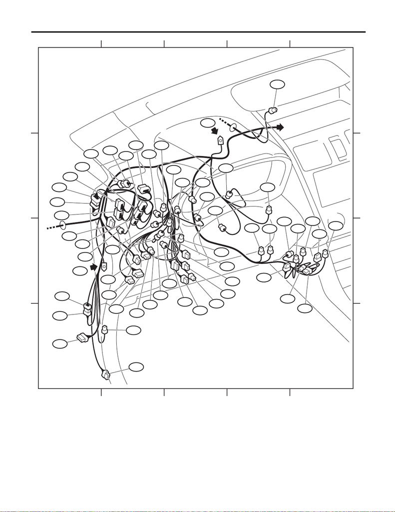

WI-441

Bulkhead Wiring Harness (In Compartment) LH

WIRING SYSTEM

WI-44619

12345

12345

A

B

C

D

A

B

C

D

RH

GB-3

B281

B225

B41

B107

B159

B52

B40

AB1

B31

B99

B101

B92

B152

B158

B550

B182

B553

AB66

B551

B162

B475

B181

B552

B572

B576

B573

B280

B23

B574

B150

B106

B180

B426

B367 B32

B65

B77

B315

B235

B424

B72

B415

B231

B555

B71

AB2

B68

B70

B558

B28

B575

GB-5

1

1:WITH ID CODE BOX:B422

WITH SECURITY CM:B559